# DM_Project

### Number.of.Open.Complaints

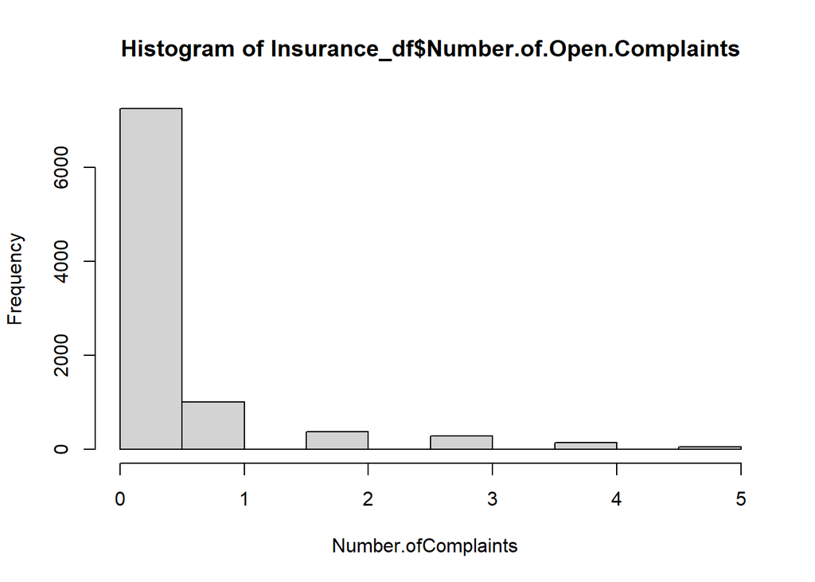

```r
hist(Insurance_df$Number.of.Open.Complaints   , xlab = "Number.ofComplaints  ")
```

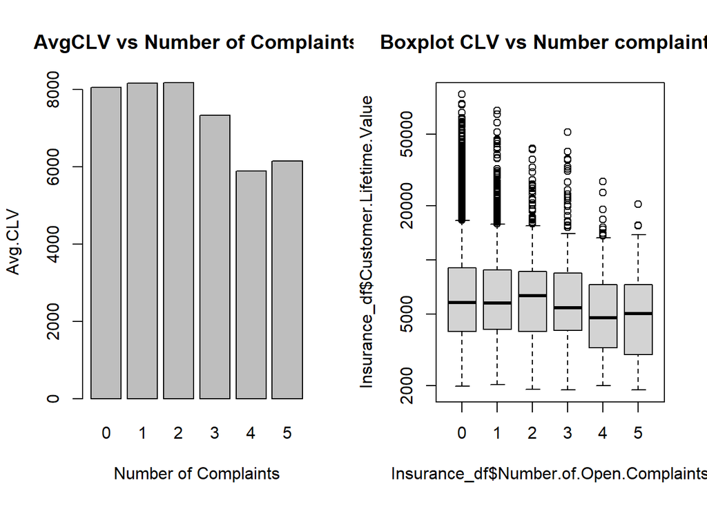

```r
# Treat Number of Complaints as Nominal Variable:
# Examine how Number of Complaints interact with outcome variable:
data.for.plot_num.of.Complain <- aggregate(Insurance_df$Customer.Lifetime.Value, by = list(as.factor(Insurance_df$Number.of.Open.Complaints)), FUN = mean)
names(data.for.plot_num.of.Complain) <- c("Number.of.Open.Complaints", "Mean_CLV")

par(mfrow = c(1,2))
barplot(height = data.for.plot_num.of.Complain$Mean_CLV, names.arg = data.for.plot_num.of.Complain$Number.of.Open.Complaints,
        xlab = "Number of Complaints", ylab = "Avg.CLV", main = "AvgCLV vs Number of Complaints")
boxplot(Insurance_df$Customer.Lifetime.Value ~ Insurance_df$Number.of.Open.Complaints, log = 'y', main = "Boxplot CLV vs Number complaints")
```

```r
# As we see on bar chart and boxplot of CLV and Number of complaints, the range and the average customer lifetime values of customers make less than 2 complaints are quite similar, and these values of customer who make more than 3 complaints are quite similar.
# We could group values of numbers complaints into 2 groups, the first group includes values 0,1,2 and the second group includes 3,4,5


Insurance_df$Num.of.Complaints = ifelse(Insurance_df$Number.of.Open.Complaints >=3,"More than 3","Less than 3") #Create a new variable replace for Number.of.Open.Complaints
```

### Number.of.Policies

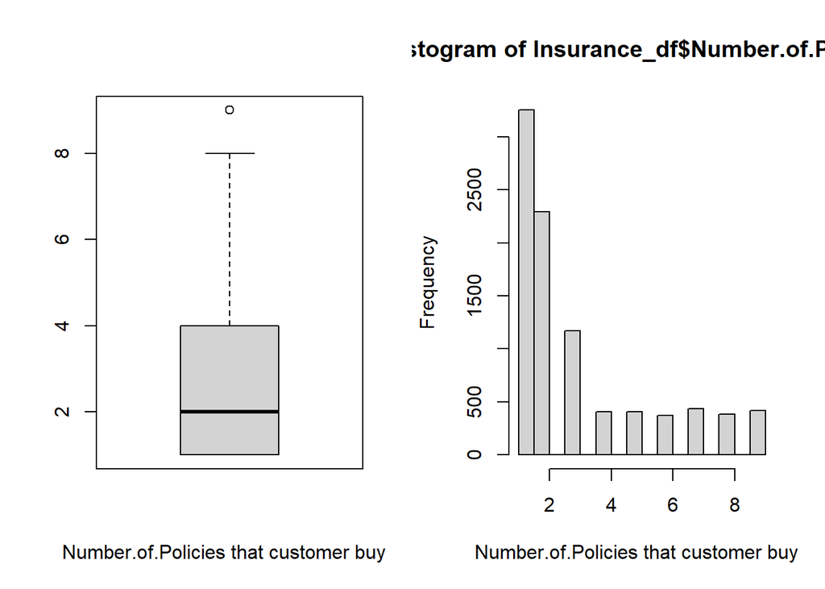

```r
par(mfrow = c(1,2))
boxplot(Insurance_df$Number.of.Policies   , xlab = "Number.of.Policies that customer buy  ")
hist(Insurance_df$Number.of.Policies   , xlab = "Number.of.Policies that customer buy  ")
```

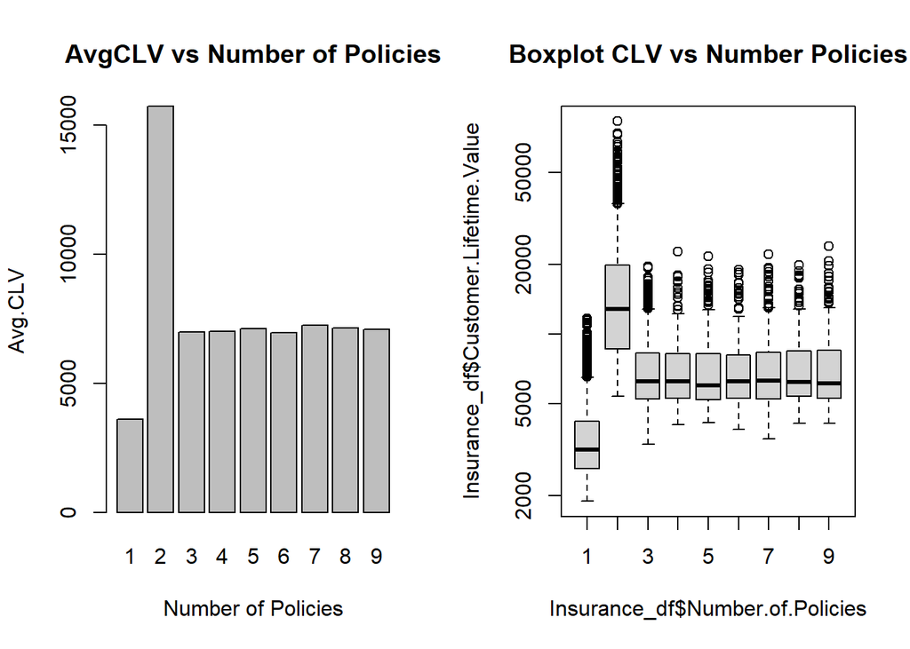

```r
# Treat Number of Policies as Nominal Variable:
# Examine how Number of Policies interact with outcome variable:
data.for.plot_num.of.Policies <- aggregate(Insurance_df$Customer.Lifetime.Value, by = list(as.factor(Insurance_df$Number.of.Policies)), FUN = mean)
names(data.for.plot_num.of.Policies) <- c("Number.of.Policies", "Mean_CLV")

par(mfrow = c(1,2))
barplot(height = data.for.plot_num.of.Policies$Mean_CLV, names.arg = data.for.plot_num.of.Policies$Number.of.Policies,
        xlab = "Number of Policies", ylab = "Avg.CLV", main = "AvgCLV vs Number of Policies")
boxplot(Insurance_df$Customer.Lifetime.Value ~ Insurance_df$Number.of.Policies, log = 'y', main = "Boxplot CLV vs Number Policies")
```

```r
# As we see on bar chart and boxplot of CLV and Number of policies that customer buy, the range and the average customer lifetime values of customers buy more than 3 policies are quite similar.
# We could group values of numbers complaints into 3 groups, the first group includes customers who buy 1 policy, the second group includes people who buy 2 policies, and the final group includes people who buy more than 3 policies

Insurance_df$New.Num.of.Policies = ifelse(Insurance_df$Number.of.Policies ==1,1,ifelse(Insurance_df$Number.of.Policies ==2,2,"More than 2")) #Create a new variable replace for Number.of.Policies
```

### Total.Claim.Amount

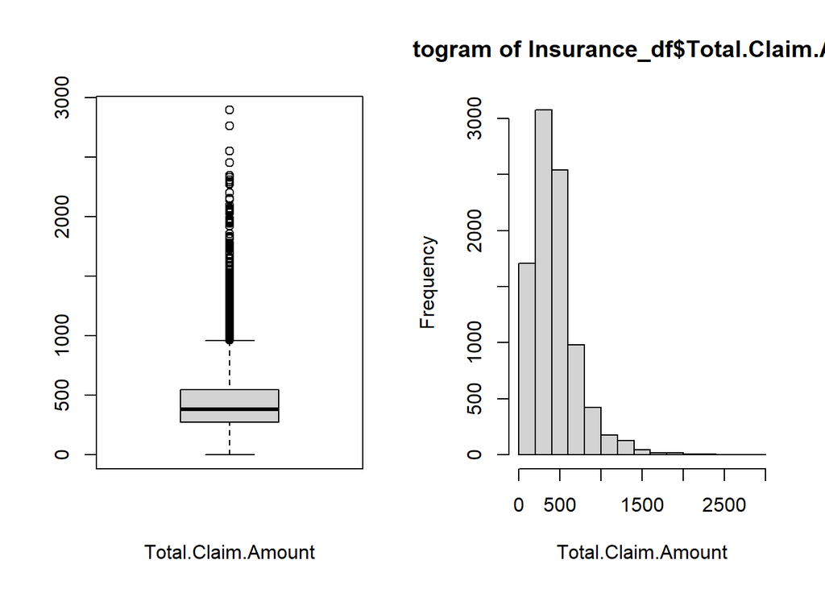

```r
par(mfrow = c(1,2))
boxplot(Insurance_df$Total.Claim.Amount, xlab = "Total.Claim.Amount")
hist(Insurance_df$Total.Claim.Amount, xlab = "Total.Claim.Amount")
```

```r
nrow(Insurance_df[Insurance_df$Total.Claim.Amount > 1000,])/length(Insurance_df$Total.Claim.Amount)*100
```

```
## [1] 4.412087
```

```r
# Max: $2893/ Min: $0/ Mean: $434/ sd: $291
# From histogram, the Total.Claim.Amount varies from $0 to $3000.
# Most of amount claim value is less than 1000
# But we have 4.4% (403) records that have value far greater than the mean.
```

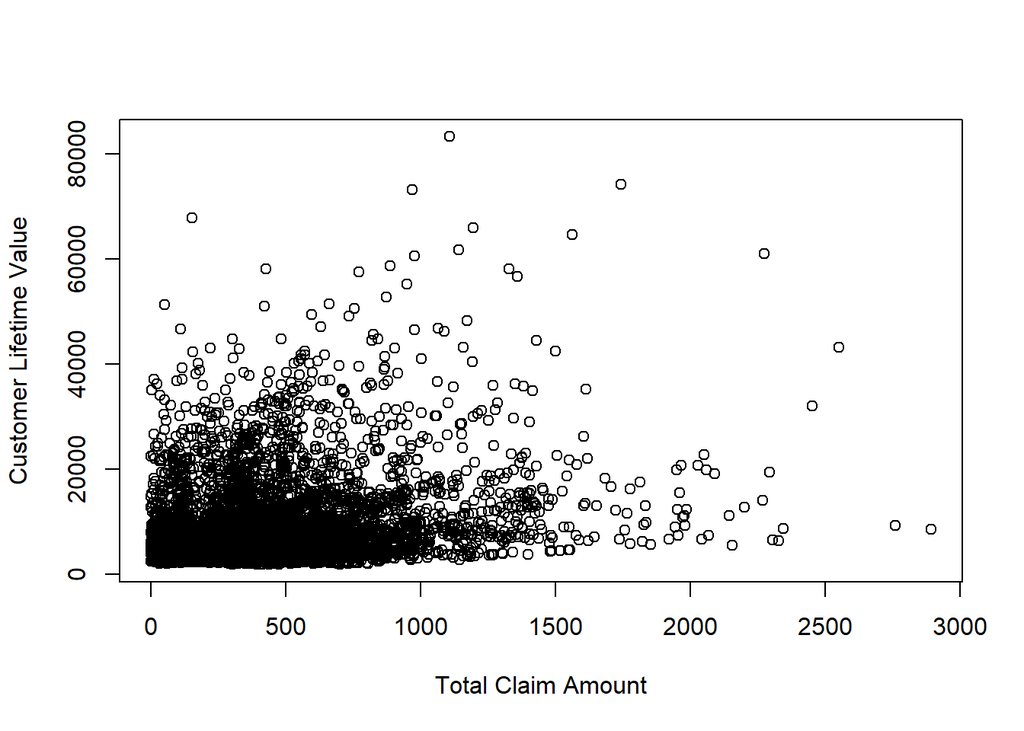

```r
plot(Insurance_df$Customer.Lifetime.Value ~ Insurance_df$Total.Claim.Amount, xlab = "Total Claim Amount", ylab = "Customer Lifetime Value")
```

There is slight positive correlation between Customer Lifetime Value and Total Claim Amount as it shows when claim amount increase, customer value tend to increase.

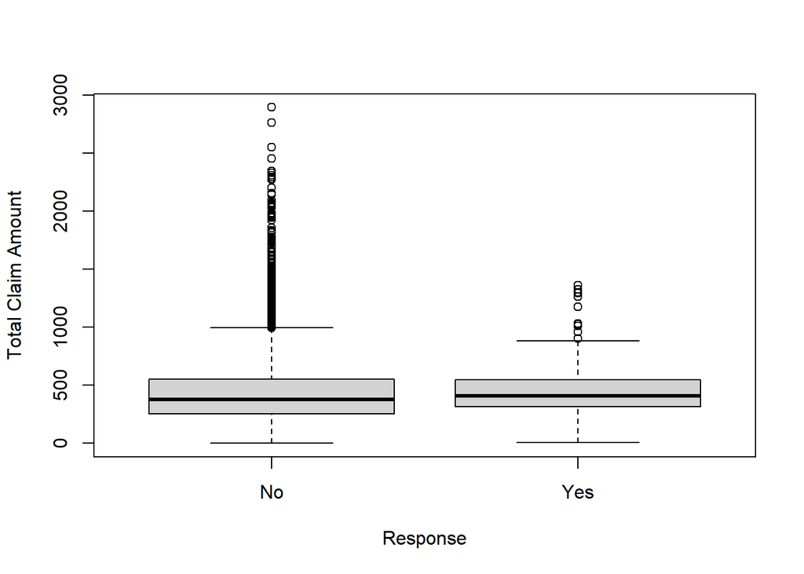

```r
boxplot(Insurance_df$Total.Claim.Amount ~ Insurance_df$Response, xlab = "Response", ylab = "Total Claim Amount")
```

### Correllation Matrix and Plot.

```r
New.Num.Val <- c("Customer.Lifetime.Value", "Income", "Monthly.Premium.Auto", "Months.Since.Last.Claim", "Months.Since.Policy.Inception", "Total.Claim.Amount")
round(cor(Insurance_df[,New.Num.Val]),3)
```

```
##                               Customer.Lifetime.Value Income
## Customer.Lifetime.Value                         1.000  0.024
## Income                                          0.024  1.000
## Monthly.Premium.Auto                            0.396 -0.017
## Months.Since.Last.Claim                         0.012 -0.027
## Months.Since.Policy.Inception                   0.009 -0.001
## Total.Claim.Amount                              0.226 -0.355
##                               Monthly.Premium.Auto Months.Since.Last.Claim
## Customer.Lifetime.Value                      0.396                   0.012
## Income                                      -0.017                  -0.027
## Monthly.Premium.Auto                         1.000                   0.005
## Months.Since.Last.Claim                      0.005                   1.000
## Months.Since.Policy.Inception                0.020                  -0.043
## Total.Claim.Amount                           0.632                   0.008
##                               Months.Since.Policy.Inception Total.Claim.Amount
## Customer.Lifetime.Value                               0.009              0.226
## Income                                               -0.001             -0.355
## Monthly.Premium.Auto                                  0.020              0.632
## Months.Since.Last.Claim                              -0.043              0.008
## Months.Since.Policy.Inception                         1.000              0.003
## Total.Claim.Amount                                    0.003              1.000
```

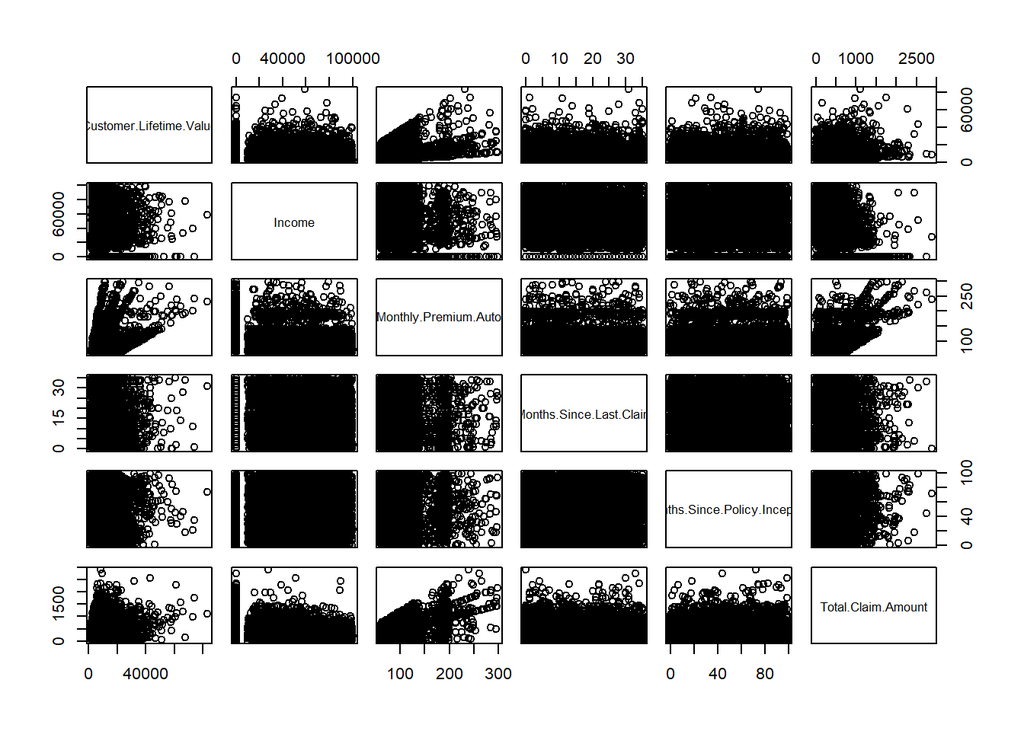

```r
pairs(Insurance_df[,New.Num.Val])
```

### CATEGORICAL VARIABLES

```r
New.Cat.val <- c("State", "Response", "Coverage", "Education", "EmploymentStatus", "Gender", "Location.Code", "Marital.Status", "Policy.Type",
                  "Renew.Offer.Type", "Sales.Channel", "Vehicle.Class", "Vehicle.Size","Num.of.Complaints", "New.Num.of.Policies")
```

### Response:

```r
# Response variable is the outcome variable for classification model:
table(Insurance_df$Response)
```

```
##
##   No  Yes
## 7826 1308
```

```r
# Values of response are unbalance, we need do do oversampling when we come to classification model.

# To make easy for computing, we transform values to 0(No) and 1(Yes)
Insurance_df$New.Response = ifelse(Insurance_df$Response == "Yes",1,0)
```

### State

```r
table(Insurance_df$State)
```

```
##
##    Arizona California     Nevada     Oregon Washington
##       1703       3150        882       2601        798
```

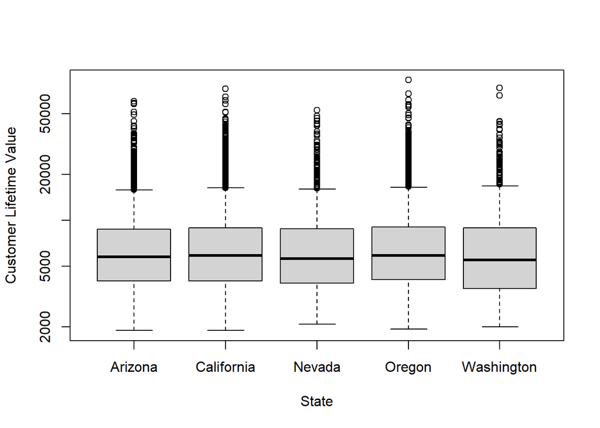

```r
# The Mode is California, most of customer live in California.

boxplot(Insurance_df$Customer.Lifetime.Value ~ Insurance_df$State, xlab = "State", ylab = "Customer Lifetime Value", log = 'y' )
```

```r
pivot(data = Insurance_df, compute = mean, variable = Customer.Lifetime.Value, by = State )
```

```
##        State Customer.Lifetime.Value_n Customer.Lifetime.Value_na
## 1    Arizona                      1703                          0
## 2 California                      3150                          0
## 3     Nevada                       882                          0
## 4     Oregon                      2601                          0
## 5 Washington                       798                          0
##   Customer.Lifetime.Value_mean
## 1                     7861.341
## 2                     8003.648
## 3                     8056.707
## 4                     8077.901
## 5                     8021.472
```

We can see on the boxplot of range of CLV vs State, and pivot table of mean_CLV vs state, there is NO huge significant difference between these state. Thus, we could **REMOVE STATE VARIABLE** out of model.

### Coverage

```r
# Coverage with CLV:
pivot(data = Insurance_df, compute = c(mean,sum), variable = Customer.Lifetime.Value, by = Coverage )
```

```
##   Coverage Customer.Lifetime.Value_n Customer.Lifetime.Value_na
## 1    Basic                      5568                          0
## 2 Extended                      2742                          0
## 3  Premium                       824                          0
##   Customer.Lifetime.Value_mean Customer.Lifetime.Value_sum
## 1                     7190.706                    40037853
## 2                     8789.678                    24101296
## 3                    10895.603                     8977977
```

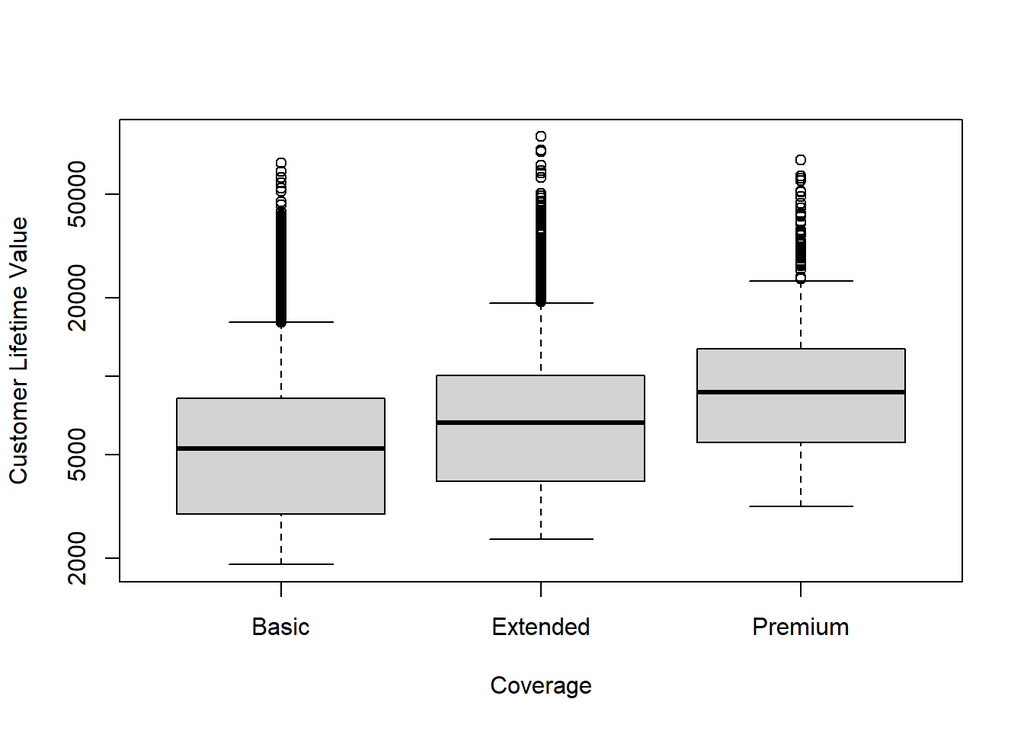

```r
boxplot(Insurance_df$Customer.Lifetime.Value ~ Insurance_df$Coverage, xlab = "Coverage", ylab = "Customer Lifetime Value", log = 'y' )
```

```r
# Coverage with Response:
Insurance_df %>%
  count(Response, Coverage) #Pivot table for Response and Coverage
```

```
##   Response Coverage    n
## 1       No    Basic 4770
## 2       No Extended 2352
## 3       No  Premium  704
## 4      Yes    Basic  798
## 5      Yes Extended  390
## 6      Yes  Premium  120
```

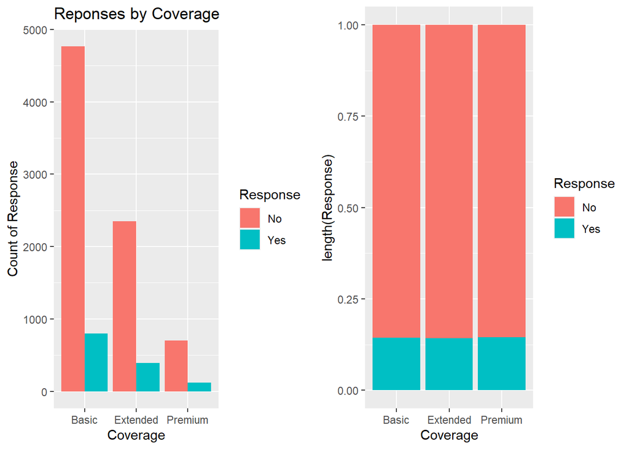

```r
Coverage.Plot1 <- ggplot(Insurance_df, aes(x = Coverage, fill = Response)) +
  geom_bar(position = "dodge") + labs(y="Count of Response",title="Reponses by Coverage")

Coverage.Plot2 <-ggplot(Insurance_df, aes(x = Coverage, y = length(Response), fill = Response)) +
  geom_col(position = "fill")  #Proportion between YES and NO
grid.arrange(Coverage.Plot1, Coverage.Plot2, ncol=2)
```

- We can see that Premium Coverage has higher CLV than Extended and Basic.
- The proportion of Yes and No response between Coverage are quite similar.